# Прогнозирование оттока клиентов

Прогнозирование оттока клиентов для оператора связи. Если выяснится, что пользователь планирует уйти, ему будут предложены промокоды и специальные условия. Команда оператора собрала персональные данные о некоторых клиентах, информацию об их тарифах и договорах.

*Описание услуг*

Оператор предоставляет два основных типа услуг:

1. Стационарную телефонную связь. Возможно подключение телефонного аппарата к нескольким линиям одновременно.
2. Интернет. Подключение может быть двух типов: через телефонную линию (DSL*,* от англ. *digital subscriber line*, «цифровая абонентская линия») или оптоволоконный кабель (*Fiber optic*).

Также доступны такие услуги:

- Интернет-безопасность: антивирус (*DeviceProtection*) и блокировка небезопасных сайтов (*OnlineSecurity*);
- Выделенная линия технической поддержки (*TechSupport*);
- Облачное хранилище файлов для резервного копирования данных (*OnlineBackup*);
- Стриминговое телевидение (*StreamingTV*) и каталог фильмов (*StreamingMovies*).

За услуги клиенты могут платить каждый месяц или заключить договор на 1–2 года. Доступны различные способы расчёта и возможность получения электронного чека.

*Описание данных*

Данные состоят из файлов, полученных из разных источников:

- `contract_new.csv` — информация о договоре;
- `personal_new.csv` — персональные данные клиента;
- `internet_new.csv` — информация об интернет-услугах;
- `phone_new.csv` — информация об услугах телефонии.

Во всех файлах столбец `customerID` содержит код клиента.

Информация о договорах актуальна на 1 февраля 2020.

## Изучение и предобработка данных

### Загружаем и изучаем данные

```python
import pandas as pd

import numpy as np

import matplotlib.pyplot as plt

import seaborn as sns

from phik import phik_matrix

from sklearn.utils.class_weight import compute_class_weight
from sklearn.model_selection import train_test_split
from sklearn.preprocessing import StandardScaler, OneHotEncoder
from sklearn.metrics import roc_auc_score
from sklearn.metrics import accuracy_score
from sklearn.linear_model import LogisticRegression
from sklearn.ensemble import RandomForestClassifier
from sklearn.dummy import DummyClassifier
from sklearn.model_selection import GridSearchCV, StratifiedKFold
from sklearn.metrics import confusion_matrix, ConfusionMatrixDisplay

import lightgbm as lgb

from catboost import CatBoostClassifier

import warnings

from tqdm import tqdm
```

```python
RANDOM_STATE=80523
```

#### Информация о договоре

```python
try:
    contract= pd.read_csv('/datasets/contract_new.csv')
    #contract= pd.read_csv('contract_new.csv')
except:
    print('no data')
contract.head()
```

|  | customerID | BeginDate | EndDate | Type | PaperlessBilling | PaymentMethod | MonthlyCharges | TotalCharges |
| --- | --- | --- | --- | --- | --- | --- | --- | --- |
| 0 | 7590-VHVEG | 2020-01-01 | No | Month-to-month | Yes | Electronic check | 29.85 | 31.04 |
| 1 | 5575-GNVDE | 2017-04-01 | No | One year | No | Mailed check | 56.95 | 2071.84 |
| 2 | 3668-QPYBK | 2019-10-01 | No | Month-to-month | Yes | Mailed check | 53.85 | 226.17 |
| 3 | 7795-CFOCW | 2016-05-01 | No | One year | No | Bank transfer (automatic) | 42.30 | 1960.6 |
| 4 | 9237-HQITU | 2019-09-01 | No | Month-to-month | Yes | Electronic check | 70.70 | 353.5 |

```python
contract.info()
```

```
<class 'pandas.core.frame.DataFrame'>
RangeIndex: 7043 entries, 0 to 7042
Data columns (total 8 columns):
 #   Column            Non-Null Count  Dtype
---  ------            --------------  -----
 0   customerID        7043 non-null   object
 1   BeginDate         7043 non-null   object
 2   EndDate           7043 non-null   object
 3   Type              7043 non-null   object
 4   PaperlessBilling  7043 non-null   object
 5   PaymentMethod     7043 non-null   object
 6   MonthlyCharges    7043 non-null   float64
 7   TotalCharges      7043 non-null   object
dtypes: float64(1), object(7)
memory usage: 440.3+ KB
```

```python
print('Количество дубликатов в данных:', contract.duplicated().sum())
```

```
Количество дубликатов в данных: 0
```

```python
# выводим количество пропущенных значений каждого стобца
contract.isna().sum()
```

```
customerID          0
BeginDate           0
EndDate             0
Type                0
PaperlessBilling    0
PaymentMethod       0
MonthlyCharges      0
TotalCharges        0
dtype: int64
```

Рассмотрим, какие значения входят в столбцы в информацие о договоре и как распределены значения между клиентами

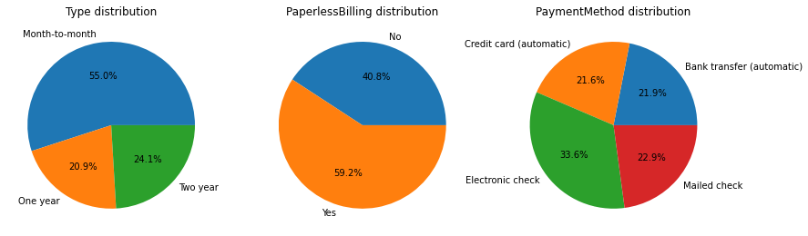

```python
# построение графика пирога с помощью группировки данных
fig, axs = plt.subplots(nrows=1, ncols=3, figsize=(14, 8))

columns = ["Type", "PaperlessBilling", "PaymentMethod"]
colors = [
    ["tab:blue", "tab:orange", "tab:green"],
    ["tab:blue", "tab:orange"],
    ["tab:blue", "tab:orange", "tab:green", "tab:red"],
]

for i, col in enumerate(columns):
    contract.groupby(col).size().plot(
        y=" ",
        kind="pie",
        autopct="%1.1f%%",
        colors=colors[i],
        ax=axs[i],
    )
    axs[i].set_title(f"{col} distribution")
    axs[i].set_ylabel("")

plt.show()
```

- `BeginDate` - тип даннх object, заменим на datetime
- Создадим столбец с количеством дней, которые пользователь является клиентом телекома (информация о договорах актуальна на 1 февраля 2020)
- `TotalCharges` - тип данных object, заменим на float
- `EndDate` тип заменим на datetime, где дат нет поставим пропуск
- Создадим колонку target, в кторой будет отражено завершен договор с клинетом или нет, 1 - пользователь больше не клиент, 0 - пользователь до сих пор клиент компании.

Столбец `TotalCharges` содержит 'пробел' вместо значений, посмотрим не сзяно ли это с тем, что пользователь не успел внести оплату еще.

```python
contract.loc[contract['TotalCharges']  == ' '].head()
```

|  | customerID | BeginDate | EndDate | Type | PaperlessBilling | PaymentMethod | MonthlyCharges | TotalCharges |
| --- | --- | --- | --- | --- | --- | --- | --- | --- |
| 488 | 4472-LVYGI | 2020-02-01 | No | Two year | Yes | Bank transfer (automatic) | 52.55 |  |
| 753 | 3115-CZMZD | 2020-02-01 | No | Two year | No | Mailed check | 20.25 |  |
| 936 | 5709-LVOEQ | 2020-02-01 | No | Two year | No | Mailed check | 80.85 |  |
| 1082 | 4367-NUYAO | 2020-02-01 | No | Two year | No | Mailed check | 25.75 |  |
| 1340 | 1371-DWPAZ | 2020-02-01 | No | Two year | No | Credit card (automatic) | 56.05 |  |

```python
contract.loc[contract['TotalCharges']  == ' ']['BeginDate'].unique()
```

```
array(['2020-02-01'], dtype=object)
```

В столбце TotalCharges встречаются пробелы вместо значений как раз в тех местах, где заканчивается актуальная информация о договорах. Скорее всего пользователь не успел внести оплату, заменим эти значения нулями.

```python
contract.loc[contract['TotalCharges']  == ' ', 'TotalCharges'] = '0'
```

```python
contract['TotalCharges'] = contract['TotalCharges'].astype('float64')
```

```python
contract['BeginDate'] = pd.to_datetime(contract['BeginDate'])
```

Создадим столбец target, в котором обозначим за 1 - пользователь больше не клиент компании, 0 - пользователь до сих пор клиент компании.

```python
contract['target'] = None
contract.loc[contract['EndDate'] == 'No', 'target'] = 0
contract.loc[contract['EndDate']!='No', 'target'] = 1
contract.head()
```

|  | customerID | BeginDate | EndDate | Type | PaperlessBilling | PaymentMethod | MonthlyCharges | TotalCharges | target |
| --- | --- | --- | --- | --- | --- | --- | --- | --- | --- |
| 0 | 7590-VHVEG | 2020-01-01 | No | Month-to-month | Yes | Electronic check | 29.85 | 31.04 | 0 |
| 1 | 5575-GNVDE | 2017-04-01 | No | One year | No | Mailed check | 56.95 | 2071.84 | 0 |
| 2 | 3668-QPYBK | 2019-10-01 | No | Month-to-month | Yes | Mailed check | 53.85 | 226.17 | 0 |
| 3 | 7795-CFOCW | 2016-05-01 | No | One year | No | Bank transfer (automatic) | 42.30 | 1960.60 | 0 |
| 4 | 9237-HQITU | 2019-09-01 | No | Month-to-month | Yes | Electronic check | 70.70 | 353.50 | 0 |

Вычислим баланс классов

```python
print(f"Количество строк в target по классам: {np.bincount(contract['target'])/len(contract['target'])*100} %")
```

```
Количество строк в target по классам: [84.36745705 15.63254295] %
```

```python
classes = np.unique(contract['target'])

class_weights = compute_class_weight(
    "balanced", classes=classes, y=contract['target'])

for class_index, class_weight in enumerate(class_weights):
    print("Класс:", classes[class_index], " Вес:", class_weight)
```

```
Класс: 0  Вес: 0.5926455738808482
Класс: 1  Вес: 3.198455949137148
```

Нет баланса классов. Количество строк в target, соответствующего 1 (пользователь больше не клиент) в несколько раз меньше веса класса 0 (пользователь до сих пор клиент компании) [84.36745705 15.63254295] %.

Создадим столбец, в котором будет содержаться количество дней, которое пользователь пользуется (или пользовался) услугами компании.

```python
contract['contract_days'] = None
contract.loc[contract['EndDate'] == 'No', 'contract_days'] = (pd.to_datetime('2020-02-01') - contract['BeginDate'])
contract.loc[contract['EndDate'] != 'No', 'contract_days'] = (pd.to_datetime(contract.loc[contract['EndDate'] != 'No', 'EndDate'] ) - contract['BeginDate'])
contract['contract_days'] = contract['contract_days'].astype(str).str.extract('(\d+) days', expand=False).astype(int)
contract.head()
```

|  | customerID | BeginDate | EndDate | Type | PaperlessBilling | PaymentMethod | MonthlyCharges | TotalCharges | target | contract_days |
| --- | --- | --- | --- | --- | --- | --- | --- | --- | --- | --- |
| 0 | 7590-VHVEG | 2020-01-01 | No | Month-to-month | Yes | Electronic check | 29.85 | 31.04 | 0 | 31 |
| 1 | 5575-GNVDE | 2017-04-01 | No | One year | No | Mailed check | 56.95 | 2071.84 | 0 | 1036 |
| 2 | 3668-QPYBK | 2019-10-01 | No | Month-to-month | Yes | Mailed check | 53.85 | 226.17 | 0 | 123 |
| 3 | 7795-CFOCW | 2016-05-01 | No | One year | No | Bank transfer (automatic) | 42.30 | 1960.60 | 0 | 1371 |
| 4 | 9237-HQITU | 2019-09-01 | No | Month-to-month | Yes | Electronic check | 70.70 | 353.50 | 0 | 153 |

```
Корреляция между общей суммой взносов и количеством дней контракта 0.8217462918018982
```

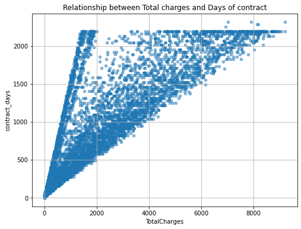

```python
contract.plot(x='TotalCharges', y='contract_days', kind='scatter', alpha=0.5, grid = True, figsize = (8,6))
# Add title to the plot
plt.title('Relationship between Total charges and Days of contract')

print('Корреляция между общей суммой взносов и количеством дней контракта', contract['TotalCharges'].corr(contract['contract_days']))
```

Соотвественно, столбцы `BeginDate`, `EndDate` можно не использовать, так как есть большая корреляция между количеством дней контракта и суммой взносов.

Рассмотрим MonthlyCharges и TotalCharges на наличие аномалий.

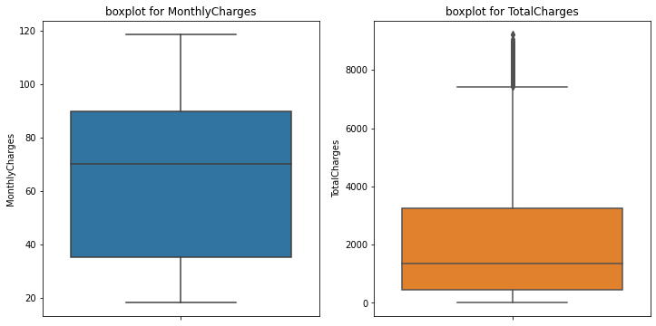

```python
fig, ax = plt.subplots(1, 2, figsize=(12, 6))

sns.boxplot(y='MonthlyCharges', data=contract, ax=ax[0])
sns.boxplot(y='TotalCharges', data=contract, ax=ax[1], color = "tab:orange")

ax[0].set_title('boxplot for MonthlyCharges')
ax[1].set_title('boxplot for TotalCharges')

plt.show()
```

```python
contract['TotalCharges'].describe()
```

```
count    7043.000000
mean     2115.312885
std      2112.742814
min         0.000000
25%       436.750000
50%      1343.350000
75%      3236.690000
max      9221.380000
Name: TotalCharges, dtype: float64
```

Большая сумма `TotalCharge`, выходящая за верхний квартиль boxplot соответствует тому, что пользователь давно пользуется услугами компании (что видно по графику корреляций между общей суммой взносов и количеством дней контракта)

Проведен анализ данных для датафрейма contract.

- дубликатов, пропусков нет
- признаки `BeginDate`, `EndDate` можно не использовать, так как есть большая корреляция между количеством дней контракта и суммой взносов `TotalCharge`
- в признаке `TotalCharges` пробелы заменили нулями
- `TotalCharges` - тип данных object, заменим на float
- создан целевой признак target (1 - пользователь больше не клиент, 0 - пользователь до сих пор клиент компании)
- исследован балланас классов (около 85/15 %)
- анамальных значений нет

#### Персональные данные клиента

```python
try:
    personal= pd.read_csv('/datasets/personal_new.csv')
    #personal= pd.read_csv('personal_new.csv')
except:
    print('no data')
personal.head()
```

|  | customerID | gender | SeniorCitizen | Partner | Dependents |
| --- | --- | --- | --- | --- | --- |
| 0 | 7590-VHVEG | Female | 0 | Yes | No |
| 1 | 5575-GNVDE | Male | 0 | No | No |
| 2 | 3668-QPYBK | Male | 0 | No | No |
| 3 | 7795-CFOCW | Male | 0 | No | No |
| 4 | 9237-HQITU | Female | 0 | No | No |

```python
personal.info()
```

```
<class 'pandas.core.frame.DataFrame'>
RangeIndex: 7043 entries, 0 to 7042
Data columns (total 5 columns):
 #   Column         Non-Null Count  Dtype
---  ------         --------------  -----
 0   customerID     7043 non-null   object
 1   gender         7043 non-null   object
 2   SeniorCitizen  7043 non-null   int64
 3   Partner        7043 non-null   object
 4   Dependents     7043 non-null   object
dtypes: int64(1), object(4)
memory usage: 275.2+ KB
```

```python
print('Количество дубликатов в данных:', personal.duplicated().sum())
```

```
Количество дубликатов в данных: 0
```

```python
# выводим количество пропущенных значений каждого стобца
personal.isna().sum()
```

```
customerID       0
gender           0
SeniorCitizen    0
Partner          0
Dependents       0
dtype: int64
```

Рассмотрим более детально, как распределены клиенты по данным features

```python
print(personal['gender'].unique())
print(personal['SeniorCitizen'].unique())
print(personal['Partner'].unique())
print(personal['Dependents'].unique())
```

```
['Female' 'Male']
[0 1]
['Yes' 'No']
['No' 'Yes']
```

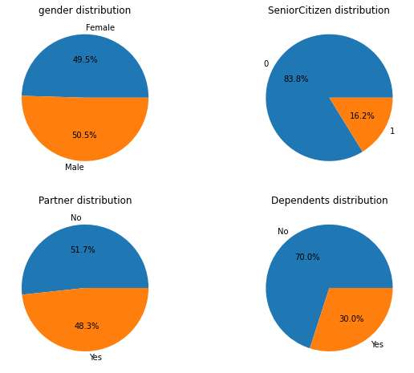

```python
fig, axs = plt.subplots(nrows=2, ncols=2, figsize=(10, 8))

columns = ["gender", "SeniorCitizen", "Partner", "Dependents"]
colors = ["tab:blue", "tab:orange"]

for i, col in enumerate(columns):
    row = i // 2
    personal.groupby(col).size().plot(
        y=" ",
        kind="pie",
        autopct="%1.1f%%",
        colors=colors,
        ax=axs[row][i % 2],
    )
    axs[row][i % 2].set_title(f"{col} distribution")
    axs[row][i % 2].set_ylabel("")

plt.show()
```

Проведен анализ данных для датафрейма personal.

- дубликатов, пропусков нет
- типы данных соответсвуют

#### Информация об интернет услугах

```python
try:
    internet= pd.read_csv('/datasets/internet_new.csv')
    #internet= pd.read_csv('internet_new.csv')
except:
    print('no data')
internet.head()
```

|  | customerID | InternetService | OnlineSecurity | OnlineBackup | DeviceProtection | TechSupport | StreamingTV | StreamingMovies |
| --- | --- | --- | --- | --- | --- | --- | --- | --- |
| 0 | 7590-VHVEG | DSL | No | Yes | No | No | No | No |
| 1 | 5575-GNVDE | DSL | Yes | No | Yes | No | No | No |
| 2 | 3668-QPYBK | DSL | Yes | Yes | No | No | No | No |
| 3 | 7795-CFOCW | DSL | Yes | No | Yes | Yes | No | No |
| 4 | 9237-HQITU | Fiber optic | No | No | No | No | No | No |

```python
internet.info()
```

```
<class 'pandas.core.frame.DataFrame'>
RangeIndex: 5517 entries, 0 to 5516
Data columns (total 8 columns):
 #   Column            Non-Null Count  Dtype
---  ------            --------------  -----
 0   customerID        5517 non-null   object
 1   InternetService   5517 non-null   object
 2   OnlineSecurity    5517 non-null   object
 3   OnlineBackup      5517 non-null   object
 4   DeviceProtection  5517 non-null   object
 5   TechSupport       5517 non-null   object
 6   StreamingTV       5517 non-null   object
 7   StreamingMovies   5517 non-null   object
dtypes: object(8)
memory usage: 344.9+ KB
```

```python
print('Количество дубликатов в данных:', internet.duplicated().sum())
```

```
Количество дубликатов в данных: 0
```

```python
# выводим количество пропущенных значений каждого стобца
internet.isna().sum()
```

```
customerID          0
InternetService     0
OnlineSecurity      0
OnlineBackup        0
DeviceProtection    0
TechSupport         0
StreamingTV         0
StreamingMovies     0
dtype: int64
```

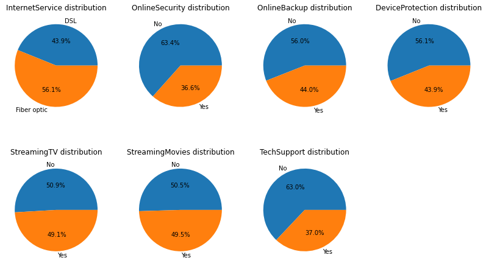

```python
fig, axs = plt.subplots(nrows=2, ncols=4, figsize=(14, 8))

columns = [
    "InternetService",
    "OnlineSecurity",
    "OnlineBackup",
    "DeviceProtection",
    "StreamingTV",
    "StreamingMovies",
    "TechSupport",
]
colors = ["tab:blue", "tab:orange"]

for i, col in enumerate(columns):
    row = i // 4
    colm = i % 4
    internet.groupby(col).size().plot(
        y=" ",
        kind="pie",
        autopct="%1.1f%%",
        colors=colors,
        ax=axs[row][colm],
    )
    axs[row][colm].set_title(f"{col} distribution")
    axs[row][colm].set_ylabel("")

axs[1][3].set_visible(False)

plt.show()
```

Проведен анализ данных для датафрейма internet.

- дубликатов, пропусков нет
- типы данных соответсвуют

#### Информация об услугах телефонии

```python
try:
    phone= pd.read_csv('/datasets/phone_new.csv')
    #phone= pd.read_csv('phone_new.csv')
except:
    print('no data')
phone.head()
```

|  | customerID | MultipleLines |
| --- | --- | --- |
| 0 | 5575-GNVDE | No |
| 1 | 3668-QPYBK | No |
| 2 | 9237-HQITU | No |
| 3 | 9305-CDSKC | Yes |
| 4 | 1452-KIOVK | Yes |

```python
phone.info()
```

```
<class 'pandas.core.frame.DataFrame'>
RangeIndex: 6361 entries, 0 to 6360
Data columns (total 2 columns):
 #   Column         Non-Null Count  Dtype
---  ------         --------------  -----
 0   customerID     6361 non-null   object
 1   MultipleLines  6361 non-null   object
dtypes: object(2)
memory usage: 99.5+ KB
```

```python
print('Количество дубликатов в данных:', phone.duplicated().sum())
```

```
Количество дубликатов в данных: 0
```

```python
# выводим количество пропущенных значений каждого стобца
phone.isna().sum()
```

```
customerID       0
MultipleLines    0
dtype: int64
```

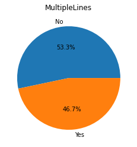

```python
phone.groupby("MultipleLines").size().plot(
    y="",
    kind="pie",
    figsize=(4, 4),
    title="MultipleLines",
    autopct="%1.1f%%",
    ylabel="",
)
plt.show()
```

Проведен анализ данных для датафрейма phone.

- дубликатов, пропусков нет
- типы данных соответсвуют

## План решения задачи

- Провести первичный анализ и предобработку данных
- Составить features и target для задачи машинного обучения. Объединить все четыре датафрейма и удалить неинформативные столбцы.
- Разработка модели прогнозирования оттока клиентов. Возможным методом может быть построение классификатора на основе машинного обучения, например, логистической регрессии или CatBoost, LightGBM.
- Для линейной регрессии необходимо будет закодировать категориальные признаки, и подготовить эти признаки и для других моделей.
- Подбор гиперпареметров моделей и выбор лучшей при сравнении метрики ROC-AUC (следить за accuracy).
- Тестирование модели.

# Цель проекта

Цель проекта - разработать модель машинного обучения оттока клиентов для оператора связи, используя персональные данные о клиентах, информацию об их тарифах и договорах. Модель должна помочь оператору определить, какие клиенты склонны уходить, и предложить им специальные условия и промокоды, чтобы удержать их.

## Подготовим выборки для обучения моделей

### Объединим таблицы:

```python
data = (
    contract.merge(personal, on="customerID")
    .merge(internet, on="customerID", how="left")
    .merge(phone, on="customerID", how="left")
)
data = data.drop(["BeginDate", "EndDate", "customerID"], axis=1)
data.head()
```

|  | Type | PaperlessBilling | PaymentMethod | MonthlyCharges | TotalCharges | target | contract_days | gender | SeniorCitizen | Partner | Dependents | InternetService | OnlineSecurity | OnlineBackup | DeviceProtection | TechSupport | StreamingTV | StreamingMovies | MultipleLines |
| --- | --- | --- | --- | --- | --- | --- | --- | --- | --- | --- | --- | --- | --- | --- | --- | --- | --- | --- | --- |
| 0 | Month-to-month | Yes | Electronic check | 29.85 | 31.04 | 0 | 31 | Female | 0 | Yes | No | DSL | No | Yes | No | No | No | No | NaN |
| 1 | One year | No | Mailed check | 56.95 | 2071.84 | 0 | 1036 | Male | 0 | No | No | DSL | Yes | No | Yes | No | No | No | No |
| 2 | Month-to-month | Yes | Mailed check | 53.85 | 226.17 | 0 | 123 | Male | 0 | No | No | DSL | Yes | Yes | No | No | No | No | No |
| 3 | One year | No | Bank transfer (automatic) | 42.30 | 1960.60 | 0 | 1371 | Male | 0 | No | No | DSL | Yes | No | Yes | Yes | No | No | NaN |
| 4 | Month-to-month | Yes | Electronic check | 70.70 | 353.50 | 0 | 153 | Female | 0 | No | No | Fiber optic | No | No | No | No | No | No | No |

### Рассмотрим корреляцию между признаками:

```python
interval_cols=['MonthlyCharges','TotalCharges','contract_days']

# вычисление матрицы коэффициентов корреляции
corr_matrix = phik_matrix(data, interval_cols = interval_cols)
```

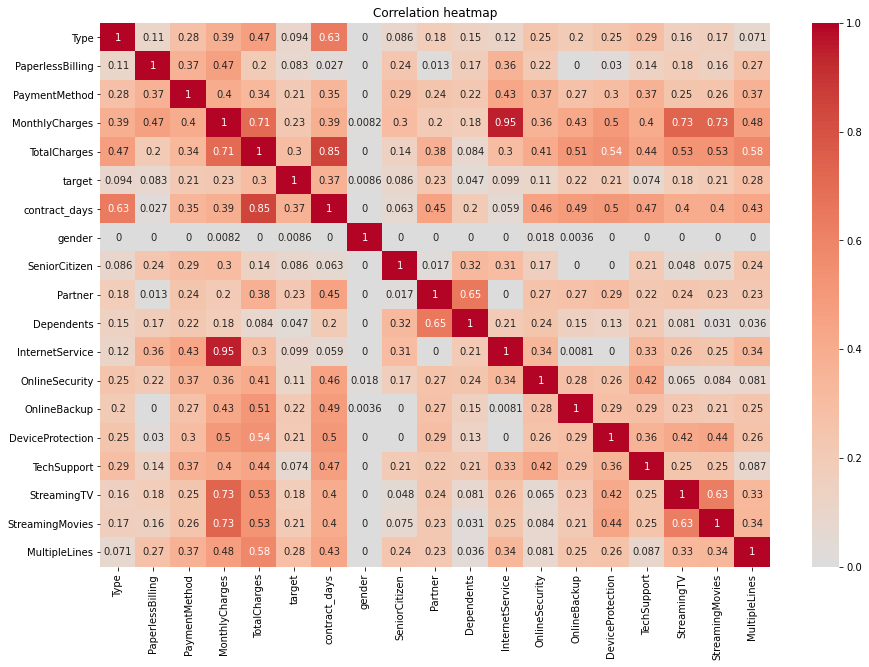

```python
# строим тепловую карту
fig, ax = plt.subplots(figsize=(15, 10))
maps = sns.heatmap(corr_matrix, annot=True, cmap='coolwarm', ax = ax, center=0)
ax.set_title('Correlation heatmap')
plt.show()
```

- Большая корреляция между признаками `InternetService` и `MonthlyCharges` (0.95). Характерихует ежемесячные платяжи за интернет.
- Заметная корреляция Стриминговое телевидение (`StreamingTV`) и каталог фильмов (`StreamingMovies`) и `MonthlyCharges` (0.73). Характеризует ежемесячные платежи за телевидение.
- Связь `MonthlyCharges` и `TotalCharges` 0.71.
- Большая корреляция между `Contract days` и `Type`, `Total Charges`
- Признаки `StreamingTV` и `StreamingMovies` несут собой практически одинаковую информацию, оставим только одну услугу и удалим - `StreamingMovies`.
- Признаки `Prtner` и `Dependences` аналогично, удалим `Dependences. Связь 0.65 (партнер и ребенок, например, часто встречается)

```python
data = data.drop(['StreamingMovies', 'Dependents', 'MonthlyCharges', 'TotalCharges' ], axis=1)
data.head()
```

|  | Type | PaperlessBilling | PaymentMethod | target | contract_days | gender | SeniorCitizen | Partner | InternetService | OnlineSecurity | OnlineBackup | DeviceProtection | TechSupport | StreamingTV | MultipleLines |
| --- | --- | --- | --- | --- | --- | --- | --- | --- | --- | --- | --- | --- | --- | --- | --- |
| 0 | Month-to-month | Yes | Electronic check | 0 | 31 | Female | 0 | Yes | DSL | No | Yes | No | No | No | NaN |
| 1 | One year | No | Mailed check | 0 | 1036 | Male | 0 | No | DSL | Yes | No | Yes | No | No | No |
| 2 | Month-to-month | Yes | Mailed check | 0 | 123 | Male | 0 | No | DSL | Yes | Yes | No | No | No | No |
| 3 | One year | No | Bank transfer (automatic) | 0 | 1371 | Male | 0 | No | DSL | Yes | No | Yes | Yes | No | NaN |
| 4 | Month-to-month | Yes | Electronic check | 0 | 153 | Female | 0 | No | Fiber optic | No | No | No | No | No | No |

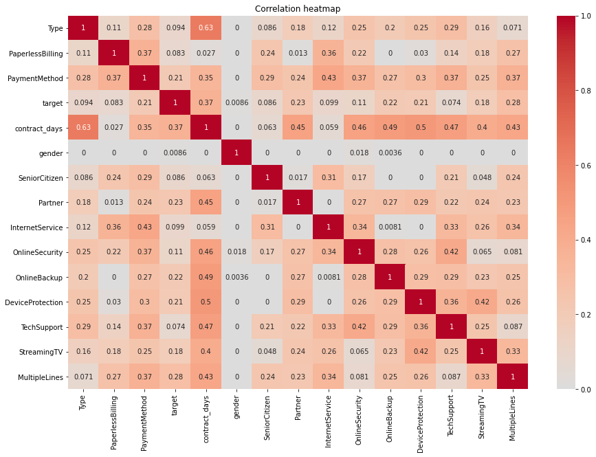

```python
# строим тепловую карту

fig, ax = plt.subplots(figsize=(15, 10))
corr_matrix = phik_matrix(data, interval_cols = interval_cols)
maps = sns.heatmap(corr_matrix, annot=True, cmap='coolwarm', ax = ax, center=0)
ax.set_title('Correlation heatmap')
plt.show()
```

### Заполним пропуски в таблице:

Заполним пропуски в признаках значением "No" - для тех у кого не подключен интернет или телефон.

```python
data['InternetService'] = data['InternetService'].fillna('No')
data['OnlineSecurity'] = data['OnlineSecurity'].fillna('No')
data['OnlineBackup'] = data['OnlineBackup'].fillna('No')
data['DeviceProtection'] = data['DeviceProtection'].fillna('No')
data['InternetService'] = data['InternetService'].fillna('No')
data['TechSupport'] = data['TechSupport'].fillna('No')
data['StreamingTV'] = data['StreamingTV'].fillna('No')
data['MultipleLines'] = data['MultipleLines'].fillna('No')
data.head()
```

|  | Type | PaperlessBilling | PaymentMethod | target | contract_days | gender | SeniorCitizen | Partner | InternetService | OnlineSecurity | OnlineBackup | DeviceProtection | TechSupport | StreamingTV | MultipleLines |
| --- | --- | --- | --- | --- | --- | --- | --- | --- | --- | --- | --- | --- | --- | --- | --- |
| 0 | Month-to-month | Yes | Electronic check | 0 | 31 | Female | 0 | Yes | DSL | No | Yes | No | No | No | No |
| 1 | One year | No | Mailed check | 0 | 1036 | Male | 0 | No | DSL | Yes | No | Yes | No | No | No |
| 2 | Month-to-month | Yes | Mailed check | 0 | 123 | Male | 0 | No | DSL | Yes | Yes | No | No | No | No |
| 3 | One year | No | Bank transfer (automatic) | 0 | 1371 | Male | 0 | No | DSL | Yes | No | Yes | Yes | No | No |
| 4 | Month-to-month | Yes | Electronic check | 0 | 153 | Female | 0 | No | Fiber optic | No | No | No | No | No | No |

Посмотрим как изменилось соотношение признаков после заполнения пропусков:

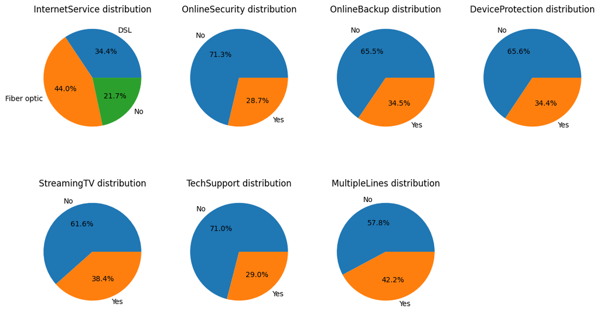

```python
fig, axs = plt.subplots(nrows=2, ncols=4, figsize=(14, 8))

columns = [
    "InternetService",
    "OnlineSecurity",
    "OnlineBackup",
    "DeviceProtection",
    "StreamingTV",
    "TechSupport",
    "MultipleLines"
]
colors = ["tab:blue", "tab:orange", "tab:green"]

for i, col in enumerate(columns):
    row = i // 4
    colm = i % 4
    data.groupby(col).size().plot(
        y=" ",
        kind="pie",
        autopct="%1.1f%%",
        colors=colors,
        ax=axs[row][colm],
    )
    axs[row][colm].set_title(f"{col} distribution")
    axs[row][colm].set_ylabel("")

axs[1][3].set_visible(False)

plt.show()
```

- У 21.7 % клиентов нет интернета
- Все остальные признаки сместились еще больше в категорию "No" после соединения таблиц и заполнении пропусков

### Закодируем категоральные признаки для моделей, которые не работают с ними напряую (например, для линейной регресии):

```python
features = data.drop('target', axis=1)
target = data['target']
features.head()
```

|  | Type | PaperlessBilling | PaymentMethod | contract_days | gender | SeniorCitizen | Partner | InternetService | OnlineSecurity | OnlineBackup | DeviceProtection | TechSupport | StreamingTV | MultipleLines |
| --- | --- | --- | --- | --- | --- | --- | --- | --- | --- | --- | --- | --- | --- | --- |
| 0 | Month-to-month | Yes | Electronic check | 31 | Female | 0 | Yes | DSL | No | Yes | No | No | No | No |
| 1 | One year | No | Mailed check | 1036 | Male | 0 | No | DSL | Yes | No | Yes | No | No | No |
| 2 | Month-to-month | Yes | Mailed check | 123 | Male | 0 | No | DSL | Yes | Yes | No | No | No | No |
| 3 | One year | No | Bank transfer (automatic) | 1371 | Male | 0 | No | DSL | Yes | No | Yes | Yes | No | No |
| 4 | Month-to-month | Yes | Electronic check | 153 | Female | 0 | No | Fiber optic | No | No | No | No | No | No |

```python
features_train, features_test, target_train, target_test  = train_test_split\
(features, target, test_size=0.25, stratify=target, random_state=RANDOM_STATE)
```

```python
cat_features = [
    "Type",
    "PaperlessBilling",
    "PaymentMethod",
    "gender",
#    "Dependents",
    "SeniorCitizen",
    "Partner",
    "InternetService",
    "OnlineSecurity",
    "OnlineBackup",
    "DeviceProtection",
    "StreamingTV",
    "TechSupport",
    "MultipleLines",
]
```

```python
features_train = features_train.reset_index()
target_train = target_train.reset_index().drop("index", axis=1).astype("int64")

features_test = features_test.reset_index()
target_test = target_test.reset_index().drop("index", axis=1).astype("int64")

encoder = OneHotEncoder(
    drop="first", handle_unknown='ignore'
)  # удаляем первый столбец чтобы не попасть в дамми-ловушку

features_train_ohe = pd.DataFrame(
    encoder.fit_transform(features_train[cat_features]).toarray(),
    columns=encoder.get_feature_names_out(),
)


features_test_ohe = pd.DataFrame(
    encoder.transform(features_test[cat_features]).toarray(),
    columns=encoder.get_feature_names_out(),
)
features_train_ohe.head()
```

|  | Type_One year | Type_Two year | PaperlessBilling_Yes | PaymentMethod_Credit card (automatic) | PaymentMethod_Electronic check | PaymentMethod_Mailed check | gender_Male | SeniorCitizen_1 | Partner_Yes | InternetService_Fiber optic | InternetService_No | OnlineSecurity_Yes | OnlineBackup_Yes | DeviceProtection_Yes | StreamingTV_Yes | TechSupport_Yes | MultipleLines_Yes |
| --- | --- | --- | --- | --- | --- | --- | --- | --- | --- | --- | --- | --- | --- | --- | --- | --- | --- |
| 0 | 1.0 | 0.0 | 1.0 | 0.0 | 0.0 | 1.0 | 0.0 | 0.0 | 0.0 | 0.0 | 0.0 | 0.0 | 0.0 | 0.0 | 1.0 | 1.0 | 1.0 |
| 1 | 0.0 | 0.0 | 1.0 | 1.0 | 0.0 | 0.0 | 0.0 | 1.0 | 1.0 | 1.0 | 0.0 | 0.0 | 0.0 | 0.0 | 1.0 | 1.0 | 1.0 |
| 2 | 1.0 | 0.0 | 0.0 | 0.0 | 1.0 | 0.0 | 1.0 | 0.0 | 0.0 | 1.0 | 0.0 | 1.0 | 0.0 | 1.0 | 1.0 | 0.0 | 0.0 |
| 3 | 0.0 | 0.0 | 1.0 | 1.0 | 0.0 | 0.0 | 0.0 | 0.0 | 1.0 | 1.0 | 0.0 | 0.0 | 0.0 | 0.0 | 0.0 | 1.0 | 1.0 |
| 4 | 0.0 | 1.0 | 0.0 | 0.0 | 0.0 | 1.0 | 0.0 | 0.0 | 0.0 | 0.0 | 0.0 | 1.0 | 1.0 | 1.0 | 1.0 | 0.0 | 1.0 |

```python
features_train_code = (
    features_train.join(features_train_ohe)
    .drop(cat_features, axis=1)
    .drop("index", axis=1)
)
features_test_code = (
    features_test.join(features_test_ohe)
    .drop(cat_features, axis=1)
    .drop("index", axis=1)
)
features_train_code.head()
```

|  | contract_days | Type_One year | Type_Two year | PaperlessBilling_Yes | PaymentMethod_Credit card (automatic) | PaymentMethod_Electronic check | PaymentMethod_Mailed check | gender_Male | SeniorCitizen_1 | Partner_Yes | InternetService_Fiber optic | InternetService_No | OnlineSecurity_Yes | OnlineBackup_Yes | DeviceProtection_Yes | StreamingTV_Yes | TechSupport_Yes | MultipleLines_Yes |
| --- | --- | --- | --- | --- | --- | --- | --- | --- | --- | --- | --- | --- | --- | --- | --- | --- | --- | --- |
| 0 | 365 | 1.0 | 0.0 | 1.0 | 0.0 | 0.0 | 1.0 | 0.0 | 0.0 | 0.0 | 0.0 | 0.0 | 0.0 | 0.0 | 0.0 | 1.0 | 1.0 | 1.0 |
| 1 | 883 | 0.0 | 0.0 | 1.0 | 1.0 | 0.0 | 0.0 | 0.0 | 1.0 | 1.0 | 1.0 | 0.0 | 0.0 | 0.0 | 0.0 | 1.0 | 1.0 | 1.0 |
| 2 | 1522 | 1.0 | 0.0 | 0.0 | 0.0 | 1.0 | 0.0 | 1.0 | 0.0 | 0.0 | 1.0 | 0.0 | 1.0 | 0.0 | 1.0 | 1.0 | 0.0 | 0.0 |
| 3 | 1218 | 0.0 | 0.0 | 1.0 | 1.0 | 0.0 | 0.0 | 0.0 | 0.0 | 1.0 | 1.0 | 0.0 | 0.0 | 0.0 | 0.0 | 0.0 | 1.0 | 1.0 |
| 4 | 1583 | 0.0 | 1.0 | 0.0 | 0.0 | 0.0 | 1.0 | 0.0 | 0.0 | 0.0 | 0.0 | 0.0 | 1.0 | 1.0 | 1.0 | 1.0 | 0.0 | 1.0 |

### Приведём численные признаки к одному масштабу

```python
#numeric = ['MonthlyCharges', 'TotalCharges', 'contract_days']
numeric = ['contract_days']
scaler = StandardScaler()
scaler.fit(features_train_code[numeric])
```

```
StandardScaler()
```

```python
features_train_code[numeric] = scaler.transform(features_train_code[numeric])
features_test_code[numeric] = scaler.transform(features_test_code[numeric])
features_train_code.head()
```

|  | contract_days | Type_One year | Type_Two year | PaperlessBilling_Yes | PaymentMethod_Credit card (automatic) | PaymentMethod_Electronic check | PaymentMethod_Mailed check | gender_Male | SeniorCitizen_1 | Partner_Yes | InternetService_Fiber optic | InternetService_No | OnlineSecurity_Yes | OnlineBackup_Yes | DeviceProtection_Yes | StreamingTV_Yes | TechSupport_Yes | MultipleLines_Yes |
| --- | --- | --- | --- | --- | --- | --- | --- | --- | --- | --- | --- | --- | --- | --- | --- | --- | --- | --- |
| 0 | -0.786476 | 1.0 | 0.0 | 1.0 | 0.0 | 0.0 | 1.0 | 0.0 | 0.0 | 0.0 | 0.0 | 0.0 | 0.0 | 0.0 | 0.0 | 1.0 | 1.0 | 1.0 |
| 1 | -0.024862 | 0.0 | 0.0 | 1.0 | 1.0 | 0.0 | 0.0 | 0.0 | 1.0 | 1.0 | 1.0 | 0.0 | 0.0 | 0.0 | 0.0 | 1.0 | 1.0 | 1.0 |
| 2 | 0.914658 | 1.0 | 0.0 | 0.0 | 0.0 | 1.0 | 0.0 | 1.0 | 0.0 | 0.0 | 1.0 | 0.0 | 1.0 | 0.0 | 1.0 | 1.0 | 0.0 | 0.0 |
| 3 | 0.467688 | 0.0 | 0.0 | 1.0 | 1.0 | 0.0 | 0.0 | 0.0 | 0.0 | 1.0 | 1.0 | 0.0 | 0.0 | 0.0 | 0.0 | 0.0 | 1.0 | 1.0 |
| 4 | 1.004346 | 0.0 | 1.0 | 0.0 | 0.0 | 0.0 | 1.0 | 0.0 | 0.0 | 0.0 | 0.0 | 0.0 | 1.0 | 1.0 | 1.0 | 1.0 | 0.0 | 1.0 |

## Обучение моделей

```python
target_train = target_train.values.ravel()
target_test = target_test.values.ravel()
```

### Логистическая регрессия

```python
%%time

# отключение предупреждений (ValueError: Solver newton-cg supports only 'l2' or 'none' penalties, got l1 penalty.)
warnings.filterwarnings(action="ignore")

# определение сетки параметров для перебора
param_grid = {
    "C": [0.1, 1, 10, 100],
    "penalty": ["l1", "l2"],
    "solver": ["liblinear", "lbfgs"],
}

cv = StratifiedKFold(n_splits=5, shuffle=True, random_state=RANDOM_STATE)

# создание модели
model = LogisticRegression(
    random_state=RANDOM_STATE
)  # , max_iter=1000)

# создание объекта GridSearchCV и запуск перебора параметров
grid_search = GridSearchCV(model, param_grid=param_grid, cv=cv, scoring="roc_auc")

grid_search.fit(features_train_code, target_train)

# выведем лучшее значение метрики ROC-AUC и соответствующие параметры
print("Лучшее значение ROC-AUC: {:.4f}".format(grid_search.best_score_))
print("Лучшие параметры: {}".format(grid_search.best_params_))

# включение всех предупреждений
warnings.resetwarnings()
```

```
Лучшее значение ROC-AUC: 0.7556
Лучшие параметры: {'C': 0.1, 'penalty': 'l2', 'solver': 'lbfgs'}
CPU times: total: 422 ms
Wall time: 1.7 s
```

```python
# Оптимальные параметры модели
best_params = grid_search.best_params_

# Обучение модели с оптимальными параметрами
best_model= model.set_params(**best_params)

best_model.fit(features_train_code, target_train)

# получение accuracy
accuracy = best_model.score(features_train_code, target_train)
print("Accuracy лучшей модели: {:.4f}".format(accuracy))
```

```
Accuracy лучшей модели: 0.8607
```

Оценим важность признаков:

```python
weights = np.abs(best_model.coef_)

# Создание сводной таблицы
feature_weights = pd.DataFrame({'feature': features_train_code.columns, 'weight': weights[0]})
feature_weights['absolute_weight'] = np.abs(feature_weights['weight'])
feature_weights = feature_weights.sort_values(by='absolute_weight', ascending=False)
feature_weights = feature_weights.drop('weight', axis = 1)
feature_weights
```

|  | feature | absolute_weight |
| --- | --- | --- |
| 2 | Type_Two year | 1.383719 |
| 1 | Type_One year | 1.034636 |
| 0 | contract_days | 0.848402 |
| 6 | PaymentMethod_Mailed check | 0.817560 |
| 17 | MultipleLines_Yes | 0.767023 |
| 9 | Partner_Yes | 0.680066 |
| 13 | OnlineBackup_Yes | 0.610340 |
| 14 | DeviceProtection_Yes | 0.420728 |
| 5 | PaymentMethod_Electronic check | 0.316598 |
| 8 | SeniorCitizen_1 | 0.296136 |
| 15 | StreamingTV_Yes | 0.212070 |
| 3 | PaperlessBilling_Yes | 0.177831 |
| 10 | InternetService_Fiber optic | 0.167647 |
| 12 | OnlineSecurity_Yes | 0.166935 |
| 16 | TechSupport_Yes | 0.147595 |
| 11 | InternetService_No | 0.133902 |
| 4 | PaymentMethod_Credit card (automatic) | 0.103005 |
| 7 | gender_Male | 0.081823 |

```python
# число признаков, от которых отказываемся по с конца рейтинга весов
n_features_to_remove_list = [4, 5, 6, 8, 11, 14]

best_model_roc_log = None
best_params_roc_log = None


results = []

warnings.filterwarnings(action="ignore")

for n_features_to_remove in tqdm(n_features_to_remove_list):
    features_to_remove = feature_weights.nsmallest(
        n_features_to_remove, "absolute_weight"
    )["feature"].values
    features_train_reduced = features_train_code.drop(columns=features_to_remove)

    model = LogisticRegression(
        random_state=RANDOM_STATE, max_iter=1000
    )
    grid_search = GridSearchCV(model, param_grid=param_grid, cv=cv, scoring="roc_auc", n_jobs=-1)
    grid_search.fit(features_train_reduced, target_train)

    # Оптимальные параметры модели
    best_params = grid_search.best_params_

    # Обучение модели с оптимальными параметрами
    best_model = model.set_params(**best_params)

    best_model.fit(features_train_reduced, target_train)
    best_score = grid_search.best_score_

    # получение accuracy
    accuracy = best_model.score(features_train_reduced, target_train)

    results.append(
        {
            "n_features_to_remove": n_features_to_remove,
            "ROC-AUC": grid_search.best_score_,
            "Accuracy": accuracy,
            "Best params": grid_search.best_params_,
        })

    if  best_model_roc_log is None or grid_search.best_score_ > best_model_roc_log.best_score_:
        best_model_roc_log = grid_search
        best_params_roc_log = best_params



results_df = pd.DataFrame(results)

# включение всех предупреждений
warnings.resetwarnings()

results_df
```

|  | n_features_to_remove | ROC-AUC | Accuracy | Best params |
| --- | --- | --- | --- | --- |
| 0 | 4 | 0.756362 | 0.861984 | {'C': 0.1, 'penalty': 'l2', 'solver': 'lbfgs'} |
| 1 | 5 | 0.757352 | 0.860659 | {'C': 0.1, 'penalty': 'l2', 'solver': 'lbfgs'} |
| 2 | 6 | 0.756970 | 0.861984 | {'C': 1, 'penalty': 'l2', 'solver': 'liblinear'} |
| 3 | 8 | 0.756149 | 0.862552 | {'C': 1, 'penalty': 'l2', 'solver': 'lbfgs'} |
| 4 | 11 | 0.748553 | 0.858387 | {'C': 0.1, 'penalty': 'l2', 'solver': 'lbfgs'} |
| 5 | 14 | 0.675673 | 0.843431 | {'C': 10, 'penalty': 'l1', 'solver': 'liblinear'} |

```python
print('Best model ROC-AUC:', best_model_roc_log.best_score_)
print('Best model params:',  best_params_roc_log)
```

```
Best model ROC-AUC: 0.757351590434655
Best model params: {'C': 0.1, 'penalty': 'l2', 'solver': 'lbfgs'}
```

### CatBoost

```python
%%time

# Задаем сетку гиперпараметров
param_grid = {
    "iterations": [50, 100, 200],
    "learning_rate": [0.05, 0.1, 0.5],
    "depth": [3, 5, 7],
}

model = CatBoostClassifier(
    class_weights=dict(enumerate(class_weights)), random_state=RANDOM_STATE, verbose=50
)

cv = StratifiedKFold(n_splits=5, shuffle=True, random_state=RANDOM_STATE)

grid_search = GridSearchCV(
    estimator=model, param_grid=param_grid, cv=cv, scoring="roc_auc", n_jobs=-1
)

# Обучаем модель с использованием GridSearchCV
grid_search.fit(features_train_code, target_train)

# выведем лучшее значение метрики ROC-AUC и соответствующие параметры
print(f"Лучшие параметры: {grid_search.best_params_}")
print(f"Лучшая оценка ROC-AUC-score: {grid_search.best_score_:.4f}")
```

```
0:	learn: 0.6191204	total: 144ms	remaining: 28.7s
50:	learn: 0.3443183	total: 269ms	remaining: 786ms
100:	learn: 0.2458358	total: 392ms	remaining: 384ms
150:	learn: 0.2105174	total: 515ms	remaining: 167ms
199:	learn: 0.1854944	total: 639ms	remaining: 0us
Лучшие параметры: {'depth': 3, 'iterations': 200, 'learning_rate': 0.5}
Лучшая оценка ROC-AUC-score: 0.9261
CPU times: total: 906 ms
Wall time: 19.1 s
```

```python
%%time

# Оптимальные параметры модели
best_params = grid_search.best_params_

# Обучение модели с оптимальными параметрами
best_model = model.set_params(**best_params)

best_model.fit(features_train_code, target_train)

# получение accuracy
accuracy = best_model.score(features_train_code, target_train)
print("Accuracy лучшей модели: {:.4f}".format(accuracy))
```

```
0:	learn: 0.6191204	total: 2.41ms	remaining: 479ms
50:	learn: 0.3443183	total: 124ms	remaining: 363ms
100:	learn: 0.2458358	total: 255ms	remaining: 250ms
150:	learn: 0.2105174	total: 385ms	remaining: 125ms
199:	learn: 0.1854944	total: 513ms	remaining: 0us
Accuracy лучшей модели: 0.9360
CPU times: total: 391 ms
Wall time: 581 ms
```

Рассмотрим важность признаков

```python
importances = best_model.feature_importances_

# Создание датафрейма с важностью признаков
importan_cat_boost = pd.DataFrame({'feature': features_train_code.columns, 'importance': importances})

# Сортировка датафрейма по убыванию важности

importan_cat_boost = importan_cat_boost.sort_values('importance', ascending=False)

importan_cat_boost
```

|  | feature | importance |
| --- | --- | --- |
| 0 | contract_days | 82.358114 |
| 2 | Type_Two year | 2.519923 |
| 17 | MultipleLines_Yes | 1.665982 |
| 9 | Partner_Yes | 1.538588 |
| 14 | DeviceProtection_Yes | 1.435207 |
| 13 | OnlineBackup_Yes | 1.381783 |
| 6 | PaymentMethod_Mailed check | 1.269101 |
| 1 | Type_One year | 1.142044 |
| 12 | OnlineSecurity_Yes | 1.073004 |
| 10 | InternetService_Fiber optic | 0.895294 |
| 3 | PaperlessBilling_Yes | 0.853307 |
| 5 | PaymentMethod_Electronic check | 0.716365 |
| 8 | SeniorCitizen_1 | 0.690962 |
| 11 | InternetService_No | 0.607106 |
| 15 | StreamingTV_Yes | 0.545905 |
| 16 | TechSupport_Yes | 0.504261 |
| 4 | PaymentMethod_Credit card (automatic) | 0.414058 |
| 7 | gender_Male | 0.388995 |

Удалим признаки с наименьшей важностью.

```python
n_features_to_remove_list = [5, 6, 7]

results = []

best_model_roc_cat = None
best_params_roc_cat = None

for n_features_to_remove in tqdm(n_features_to_remove_list):
    features_to_remove = importan_cat_boost.nsmallest(n_features_to_remove, 'importance')['feature'].values
    features_train_reduced = features_train_code.drop(columns=features_to_remove)

    # Задаем сетку гиперпараметров
    param_grid = {
    "iterations": [50, 100, 200],
    "learning_rate": [0.05, 0.1, 0.5],
    "depth": [3, 5, 7]
    }

    model = CatBoostClassifier(
    class_weights=dict(enumerate(class_weights)), random_state=RANDOM_STATE, verbose=0
    )

    cv = StratifiedKFold(n_splits=5, shuffle=True, random_state=RANDOM_STATE)

    grid_search = GridSearchCV(
    estimator=model, param_grid=param_grid, cv=cv, scoring="roc_auc", n_jobs=-1
    )

    # Обучаем модель с использованием GridSearchCV
    grid_search.fit(features_train_reduced, target_train)
    # Оптимальные параметры модели
    best_params = grid_search.best_params_
    # Обучение модели с оптимальными параметрами
    best_model = model.set_params(**best_params)
    best_model.fit(features_train_reduced, target_train)

    # получение accuracy
    accuracy = best_model.score(features_train_reduced, target_train)

    results.append({'n_features_to_remove': n_features_to_remove,
                    'ROC-AUC': grid_search.best_score_,
                    'Accuracy': accuracy,
                    'Best params': grid_search.best_params_})

    if  best_model_roc_cat is None or grid_search.best_score_ > best_model_roc_cat.best_score_:
        best_model_roc_cat = grid_search
        best_params_roc_cat = best_params

results_df = pd.DataFrame(results)


print('Best model ROC-AUC:', best_model_roc_cat.best_score_)
print('Best model params:',  best_params_roc_cat)
```

```
Best model ROC-AUC: 0.933317649624524
Best model params: {'depth': 3, 'iterations': 200, 'learning_rate': 0.5}
```

```python
results_df
```

|  | n_features_to_remove | ROC-AUC | Accuracy | Best params |
| --- | --- | --- | --- | --- |
| 0 | 5 | 0.928221 | 0.931465 | {'depth': 3, 'iterations': 200, 'learning_rate... |
| 1 | 6 | 0.931142 | 0.929951 | {'depth': 3, 'iterations': 200, 'learning_rate... |
| 2 | 7 | 0.933318 | 0.929761 | {'depth': 3, 'iterations': 200, 'learning_rate... |

### LightGBM

```python
%%time

# замена пробелов в именах признаков на символ подчеркивания
# features_train_lgbm = features_train_code.rename(columns=lambda x: x.replace(' ', '_'), inplace=True)

# Настройка сетки параметров
param_grid = {
    'learning_rate': [0.01, 0.05, 0.1, 0.2],
    'max_depth': [2, 3, 5, 7],
    'n_estimators': [50, 100, 200, 1000],
    'num_leaves': [2, 3, 4, 5],
}

model = lgb.LGBMClassifier(class_weight='balanced', random_state=RANDOM_STATE, verbosity=0, force_col_wise = True)

cv = StratifiedKFold(n_splits=5, shuffle=True, random_state=RANDOM_STATE)

grid_search = GridSearchCV(model, param_grid, cv=cv, scoring="roc_auc", n_jobs=-1)

# Обучаем модель
grid_search.fit(features_train_code, target_train)

# выведем лучшее значение метрики ROC-AUC и соответствующие параметры
print(f"Лучшие параметры: {grid_search.best_params_}")
print(f"Лучшая оценка ROC-AUC-score: {grid_search.best_score_:.4f}")
```

```
[LightGBM] [Warning] Found whitespace in feature_names, replace with underlines
Лучшие параметры: {'learning_rate': 0.2, 'max_depth': 2, 'n_estimators': 1000, 'num_leaves': 4}
Лучшая оценка ROC-AUC-score: 0.9258
CPU times: total: 13.6 s
Wall time: 1min 27s
```

```python
# Оптимальные параметры модели
best_params = grid_search.best_params_

# Обучение модели с оптимальными параметрами
best_model = model.set_params(**best_params)

best_model.fit(features_train_code, target_train)

# получение accuracy
accuracy = best_model.score(features_train_code, target_train)
print("Accuracy лучшей модели: {:.4f}".format(accuracy))
```

```
[LightGBM] [Warning] Found whitespace in feature_names, replace with underlines
Accuracy лучшей модели: 0.9207
```

Рассмотрим важность признаков:

```python
importances = best_model.feature_importances_

# Создание датафрейма с важностью признаков
importan = pd.DataFrame({'feature': features_train_code.columns, 'importance': importances})

# Сортировка датафрейма по убыванию важности
importan = importan.sort_values('importance', ascending=False)
importan
```

|  | feature | importance |
| --- | --- | --- |
| 0 | contract_days | 2260 |
| 2 | Type_Two year | 72 |
| 14 | DeviceProtection_Yes | 58 |
| 1 | Type_One year | 57 |
| 7 | gender_Male | 54 |
| 13 | OnlineBackup_Yes | 54 |
| 9 | Partner_Yes | 49 |
| 8 | SeniorCitizen_1 | 48 |
| 4 | PaymentMethod_Credit card (automatic) | 44 |
| 3 | PaperlessBilling_Yes | 41 |
| 11 | InternetService_No | 38 |
| 5 | PaymentMethod_Electronic check | 37 |
| 16 | TechSupport_Yes | 35 |
| 6 | PaymentMethod_Mailed check | 33 |
| 17 | MultipleLines_Yes | 33 |
| 12 | OnlineSecurity_Yes | 32 |
| 10 | InternetService_Fiber optic | 30 |
| 15 | StreamingTV_Yes | 25 |

```python
n_features_to_remove_list = [5, 6, 7]

results = []

best_model_roc_gbm = None
best_params_roc_gbm = None

for n_features_to_remove in tqdm(n_features_to_remove_list):
    features_to_remove = importan.nsmallest(n_features_to_remove, "importance")[
        "feature"
    ].values
    features_train_reduced = features_train_code.drop(columns=features_to_remove)

    # Настройка сетки параметров
    param_grid = {
        "learning_rate": [0.01, 0.05, 0.1, 0.2],
        "max_depth": [2, 3, 5, 7],
        "n_estimators": [50, 100, 200, 1000],
        "num_leaves": [2, 3, 4, 5],
    }

    model = lgb.LGBMClassifier(
        class_weight="balanced",
        random_state=RANDOM_STATE,
        verbosity=0,
        force_col_wise=True,
    )

    cv = StratifiedKFold(n_splits=5, shuffle=True, random_state=RANDOM_STATE)

    grid_search = GridSearchCV(model, param_grid, cv=cv, scoring="roc_auc", n_jobs=-1)

    # Обучаем модель с использованием GridSearchCV
    grid_search.fit(features_train_reduced, target_train)
    # Оптимальные параметры модели
    best_params = grid_search.best_params_
    # Обучение модели с оптимальными параметрами
    best_model = model.set_params(**best_params)
    best_model.fit(features_train_reduced, target_train)

    # получение accuracy
    accuracy = best_model.score(features_train_reduced, target_train)

    results.append(
        {
            "n_features_to_remove": n_features_to_remove,
            "ROC-AUC": grid_search.best_score_,
            "Accuracy": accuracy,
            "Best params": grid_search.best_params_,
        }
    )

    if best_model_roc_gbm is None or grid_search.best_score_ > best_model_roc_gbm.best_score_:
        best_model_roc_gbm = grid_search
        best_params_roc_gbm = best_params

results_df = pd.DataFrame(results)


print("Best model ROC-AUC:", best_model_roc_gbm.best_score_)
print("Best model params:", best_params_roc_gbm)
```

```
[LightGBM] [Warning] Found whitespace in feature_names, replace with underlines
[LightGBM] [Warning] Found whitespace in feature_names, replace with underlines
```

```
[LightGBM] [Warning] Found whitespace in feature_names, replace with underlines
[LightGBM] [Warning] Found whitespace in feature_names, replace with underlines
```

```
[LightGBM] [Warning] Found whitespace in feature_names, replace with underlines
[LightGBM] [Warning] Found whitespace in feature_names, replace with underlines
```

```
Best model ROC-AUC: 0.9239885690501117
Best model params: {'learning_rate': 0.2, 'max_depth': 2, 'n_estimators': 1000, 'num_leaves': 4}
```

```python
results_df
```

|  | n_features_to_remove | ROC-AUC | Accuracy | Best params |
| --- | --- | --- | --- | --- |
| 0 | 5 | 0.923416 | 0.908747 | {'learning_rate': 0.2, 'max_depth': 2, 'n_esti... |
| 1 | 6 | 0.923989 | 0.908936 | {'learning_rate': 0.2, 'max_depth': 2, 'n_esti... |
| 2 | 7 | 0.922625 | 0.907421 | {'learning_rate': 0.2, 'max_depth': 2, 'n_esti... |

### RandomForest

```python
param_grid = {
    'n_estimators': [100, 200, 500],
    'max_depth': [3, 5, 7, 10, 20],
    'criterion': ['gini', 'entropy']
}

model = RandomForestClassifier(class_weight='balanced', random_state=RANDOM_STATE)

cv = StratifiedKFold(n_splits=5, shuffle=True, random_state=RANDOM_STATE)

grid_search = GridSearchCV(model, param_grid, cv=cv, scoring="roc_auc", n_jobs=-1)


# Обучаем модель
grid_search.fit(features_train_code, target_train)

# выведем лучшее значение метрики ROC-AUC и соответствующие параметры
print(f"Лучшие параметры: {grid_search.best_params_}")
print(f"Лучшая оценка ROC-AUC-score: {grid_search.best_score_:.4f}")
```

```
Лучшие параметры: {'criterion': 'gini', 'max_depth': 7, 'n_estimators': 500}
Лучшая оценка ROC-AUC-score: 0.8300
```

```python
# Оптимальные параметры модели
best_params = grid_search.best_params_

# Обучение модели с оптимальными параметрами
best_model = model.set_params(**best_params)

best_model.fit(features_train_code, target_train)

# получение accuracy
accuracy = best_model.score(features_train_code, target_train)
print("Accuracy лучшей модели: {:.4f}".format(accuracy))
```

```
Accuracy лучшей модели: 0.7906
```

```python
importances = best_model.feature_importances_

# Создание датафрейма с важностью признаков
importan = pd.DataFrame({'feature': features_train_code.columns, 'importance': importances})

# Сортировка датафрейма по убыванию важности
importan = importan.sort_values('importance', ascending=False)
importan
```

|  | feature | importance |
| --- | --- | --- |
| 0 | contract_days | 0.439578 |
| 17 | MultipleLines_Yes | 0.091003 |
| 9 | Partner_Yes | 0.068384 |
| 2 | Type_Two year | 0.058364 |
| 13 | OnlineBackup_Yes | 0.056570 |
| 14 | DeviceProtection_Yes | 0.055037 |
| 6 | PaymentMethod_Mailed check | 0.039205 |
| 15 | StreamingTV_Yes | 0.027284 |
| 1 | Type_One year | 0.025990 |
| 4 | PaymentMethod_Credit card (automatic) | 0.020687 |
| 12 | OnlineSecurity_Yes | 0.017281 |
| 16 | TechSupport_Yes | 0.017082 |
| 10 | InternetService_Fiber optic | 0.016476 |
| 3 | PaperlessBilling_Yes | 0.015320 |
| 5 | PaymentMethod_Electronic check | 0.013900 |
| 8 | SeniorCitizen_1 | 0.013593 |
| 7 | gender_Male | 0.013427 |
| 11 | InternetService_No | 0.010820 |

```python
n_features_to_remove_list = [6, 12, 15]

results = []

best_model_roc_rf = None
best_params_roc_rf = None

for n_features_to_remove in tqdm(n_features_to_remove_list):
    features_to_remove = importan.nsmallest(n_features_to_remove, 'importance')['feature'].values
    features_train_reduced = features_train_code.drop(columns=features_to_remove)

    # Настройка сетки параметров
    param_grid = {
    'n_estimators': [100, 200, 500],
    'max_depth': [3, 5, 7, 10, 20],
    'criterion': ['gini', 'entropy']
    }

    model = RandomForestClassifier(class_weight='balanced', random_state=RANDOM_STATE)

    cv = StratifiedKFold(n_splits=5, shuffle=True, random_state=RANDOM_STATE)

    grid_search = GridSearchCV(model, param_grid, cv=cv, scoring="roc_auc", n_jobs=-1)

    # Обучаем модель с использованием GridSearchCV
    grid_search.fit(features_train_reduced, target_train)
    # Оптимальные параметры модели
    best_params = grid_search.best_params_
    # Обучение модели с оптимальными параметрами
    best_model = model.set_params(**best_params)
    best_model.fit(features_train_reduced, target_train)

    # получение accuracy
    accuracy = best_model.score(features_train_reduced, target_train)

    results.append({'n_features_to_remove': n_features_to_remove,
                    'ROC-AUC': grid_search.best_score_,
                    'Accuracy': accuracy,
                    'Best params': grid_search.best_params_})

    if best_model_roc_rf is None or grid_search.best_score_ > best_model_roc_rf.best_score_:
        best_model_roc_rf = grid_search
        best_params_roc_rf = best_params

results_df = pd.DataFrame(results)

print('Best model ROC-AUC:', best_model_roc_rf.best_score_)
print('Best model params:', best_params_roc_rf)
```

```
Best model ROC-AUC: 0.8612904164145331
Best model params: {'criterion': 'entropy', 'max_depth': 20, 'n_estimators': 500}
```

```python
results_df
```

|  | n_features_to_remove | ROC-AUC | Accuracy | Best params |
| --- | --- | --- | --- | --- |
| 0 | 6 | 0.829258 | 0.778872 | {'criterion': 'entropy', 'max_depth': 7, 'n_es... |
| 1 | 12 | 0.820390 | 0.728323 | {'criterion': 'gini', 'max_depth': 5, 'n_estim... |
| 2 | 15 | 0.861290 | 0.917645 | {'criterion': 'entropy', 'max_depth': 20, 'n_e... |

### DammyClassifier

```python
model = DummyClassifier(strategy='stratified', random_state=RANDOM_STATE)

# Обучаем модель
model.fit(features_train_code, target_train)

# выведем значение метрики ROC-AUC, accuracy

target_predict = model.predict(features_test_code)

# Получение вероятностей принадлежности к положительному классу
target_pred_proba = model.predict_proba(features_test_code)[:, 1]

# Вычисление ROC-AUC
roc_auc_dummy = roc_auc_score(target_test, target_pred_proba)
print("ROC-AUC:", roc_auc_dummy)

accuracy = accuracy_score(target_test, target_predict)
print("Accuracy:", accuracy)
```

```
ROC-AUC: 0.4779652514376606
Accuracy: 0.7291311754684838
```

## Тестирование модели

```python
models = ['LogisticRegression', 'CatBoostClassifier', 'LGBMClassifier', 'RandomForestClassifier', 'DummyClassifier']
roc_auc = [best_model_roc_log.best_score_, best_model_roc_cat.best_score_, best_model_roc_gbm.best_score_, best_model_roc_rf.best_score_, roc_auc_dummy]

df = pd.DataFrame({'ROC-AUC': roc_auc}, index=models)
df.index.name = 'Model'
df = df.sort_values(by='ROC-AUC', ascending=False)
df
```

| Model | ROC-AUC |
| --- | --- |
| CatBoostClassifier | 0.933318 |
| LGBMClassifier | 0.923989 |
| RandomForestClassifier | 0.861290 |
| LogisticRegression | 0.757352 |
| DummyClassifier | 0.477965 |

- Среди всех использованных моделей машинного обучения, лучшей по метрике ROC-AUC оказалась модель CatBoostClassifier
- Возьмем для теста лучшую модель с ограниченным числом признаков

```python
n_features_to_remove = 7

features_to_remove = importan_cat_boost.nsmallest(n_features_to_remove, 'importance')['feature'].values

# Удаление отобранных признаков из датасета
features_train_reduced  = features_train_code.copy()
features_train_reduced = features_train_reduced.drop(columns=features_to_remove)

features_test_reduced  = features_test_code.copy()
features_test_reduced = features_test_reduced.drop(columns=features_to_remove)

features_train_reduced.head()
```

|  | contract_days | Type_One year | Type_Two year | PaperlessBilling_Yes | PaymentMethod_Mailed check | Partner_Yes | InternetService_Fiber optic | OnlineSecurity_Yes | OnlineBackup_Yes | DeviceProtection_Yes | MultipleLines_Yes |
| --- | --- | --- | --- | --- | --- | --- | --- | --- | --- | --- | --- |
| 0 | -0.786476 | 1.0 | 0.0 | 1.0 | 1.0 | 0.0 | 0.0 | 0.0 | 0.0 | 0.0 | 1.0 |
| 1 | -0.024862 | 0.0 | 0.0 | 1.0 | 0.0 | 1.0 | 1.0 | 0.0 | 0.0 | 0.0 | 1.0 |
| 2 | 0.914658 | 1.0 | 0.0 | 0.0 | 0.0 | 0.0 | 1.0 | 1.0 | 0.0 | 1.0 | 0.0 |
| 3 | 0.467688 | 0.0 | 0.0 | 1.0 | 0.0 | 1.0 | 1.0 | 0.0 | 0.0 | 0.0 | 1.0 |
| 4 | 1.004346 | 0.0 | 1.0 | 0.0 | 1.0 | 0.0 | 0.0 | 1.0 | 1.0 | 1.0 | 1.0 |

```python
model = best_model_roc_cat
model.fit(features_train_reduced, target_train)
```

```
GridSearchCV(cv=StratifiedKFold(n_splits=5, random_state=80523, shuffle=True),
             estimator=<catboost.core.CatBoostClassifier object at 0x000001BC2794D610>,
             n_jobs=-1,
             param_grid={'depth': [3, 5, 7], 'iterations': [50, 100, 200],
                         'learning_rate': [0.05, 0.1, 0.5]},
             scoring='roc_auc')
```

```python
target_predict = model.predict(features_test_reduced)

# Получение вероятностей принадлежности к положительному классу
target_pred_proba = model.predict_proba(features_test_reduced)[:, 1]

# Вычисление ROC-AUC
roc_auc = roc_auc_score(target_test, target_pred_proba)
print("ROC-AUC:", roc_auc)

accuracy = accuracy_score(target_test, target_predict)
print("Accuracy:", accuracy)
```

```
ROC-AUC: 0.9289563195888902
Accuracy: 0.8949460533787621
```

```python
# Расчет матрицы ошибок
cm = confusion_matrix(target_test, target_predict, normalize= 'true')
print(cm)
```

```
[[0.92193809 0.07806191]
 [0.25090909 0.74909091]]
```

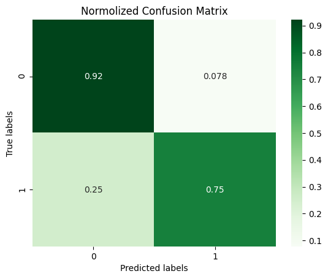

```python
sns.heatmap(cm, annot=True, cmap='Greens')

plt.xlabel("Predicted labels")
plt.ylabel("True labels")
plt.title("Normolized Confusion Matrix")
plt.show()
```

- 75 % положительных объектов были правильно классифицированы как положительные (True Positives)
- 25 % положительных объектов были неправильно классифицированы как отрицательные (False Negatives)
- 8 % отрицательных объектов были неправильно классифицированы как положительные (False Positives)
- 92 % отрицательных объектов были правильно классифицированы как отрицательные (True Negatives)
- Дисбаланс классов влияет на матрицу ошибок.

На тестовой выборке:

- ROC-AUC: 0.9289563195888902
- Accuracy: 0.8949460533787621

## Отчет

Цель проекта - разработать модель машинного обучения оттока клиентов для оператора связи, используя персональные данные о клиентах, информацию об их тарифах и договорах. Модель должна помочь оператору определить, какие клиенты склонны уходить, и предложить им специальные условия и промокоды, чтобы удержать их.

- Проведен первичный анализ и предобработка данных. Данные проверены на наличие пропусков, дубликатов, выбросов и ошибок в данных, а также определены типы переменных и их распределение.
- Определена целевая переменная и признаки. Целевая переменная (target) будет являться бинарным признаком, указывающим, ушел клиент или остался. Features могут включать в себя информацию о демографии, тарифах, услугах, использовании связи, а также другие социально-экономические и финансовые характеристики клиента.
- Подготовлены данные для модели. Для логистической регрессии необходимо закодировать категориальные признаки, а также отмасштабировать количественные признаки.
- Проведен анализ корреляции между признаками. По результатам анализа удалены признаки, имеющие наибольшую корреляцию.
- Разработаны модели прогнозирования оттока клиентов, используя методы машинного обучения, такие как LogisticRegression или CatBoost, LightGBM, RandomForrest. Использована кросс-валидация и выбор лучшей модели на основе метрики ROC-AUC.
- Проведена оценка константной модели для проверки адекватности качества предсказаний.
- Проведен анализ важности признаков по анализу каждой модели, подбор гиперпараметров.
- Лучшая модель протестирована на отложенном наборе данных и оценена ее точность прогнозирования. Лучшей моделью оказался CatBoost: 'depth': 3, 'iterations': 200, 'learning_rate': 0.5. 7 признакков меньшей важности удалены из датасета.
- ROC AUC на тестовой выборке : 0.93, что говорит о том, что модель классификации может хорошо предсказывать, кто из клиентов склонен уйти и кто останется.
- Модель позволит оператору связи оптимизировать свою стратегию удержания клиентов и принимать более обоснованные решения по предоставлению специальных условий и промокодов тем клиентам, которые наиболее вероятно покинут оператора.